# Sündmusanalüüs

Sotsiaalse analüüsi meetodid: kvantitatiivne lähenemine

Indrek Soidla

8 4 2022

Loeme sisse vajalikud paketid.

```r
library(survival)
library(essurvey)
library(weights)
library(dplyr)
library(descr)
library(survminer)
```

## Loengunäide

Teeme harjutuseks R-s läbi elukestuskõvera näite loenguslaididelt. Laeme sisse andmed ja vaatame andmed üle.

```r
andm <- read.csv2("data/syndmusanalnaide2.csv")
andm
```

```
##    jrjk  aeg syndmus i
## 1     1  2.0       1 1
## 2     2  2.5       1 2
## 3     3  2.8       1 3
## 4     4  2.8       1 3
## 5     5  3.5       1 4
## 6     6  4.2       0 5
## 7     7  5.5       1 6
## 8     8  7.0       0 7
## 9     9  8.0       1 8
## 10   10 10.0       0 9
```

```r
fit <- survfit(Surv(aeg, syndmus) ~ 1, data = andm)
summary(fit)
```

```
## Call: survfit(formula = Surv(aeg, syndmus) ~ 1, data = andm)
##
##  time n.risk n.event survival std.err lower 95% CI upper 95% CI
##   2.0     10       1    0.900  0.0949       0.7320        1.000
##   2.5      9       1    0.800  0.1265       0.5868        1.000
##   2.8      8       2    0.600  0.1549       0.3617        0.995
##   3.5      6       1    0.500  0.1581       0.2690        0.929
##   5.5      4       1    0.375  0.1606       0.1620        0.868
##   8.0      2       1    0.188  0.1550       0.0371        0.948
```

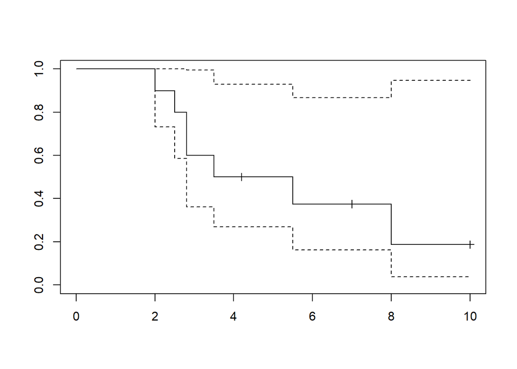

```r
plot(fit, conf.int = F, mark.time = F)
plot(fit, conf.int = F, mark.time = T)
plot(fit, conf.int = T, mark.time = T)
```

## Kaplan-Meier

Kasutame ESS 2018. aasta Eesti andmeid, arvutame elukestuskõverad esimese lapse sünni vanuse kohta.

Laeme sisse andmed.

```r
library(essurvey)
set_email("indrek.soidla@ut.ee")

ee9 <- import_country(country = "Estonia", rounds = 9)
```

Tunnuses `fcldbrn` on andmed selle kohta, mis aastal sündis vastajal esimene laps. Vaatame selle tunnuse jaotust histogrammil, kaalume ka andmed läbi järelkihistamiskaaludega.

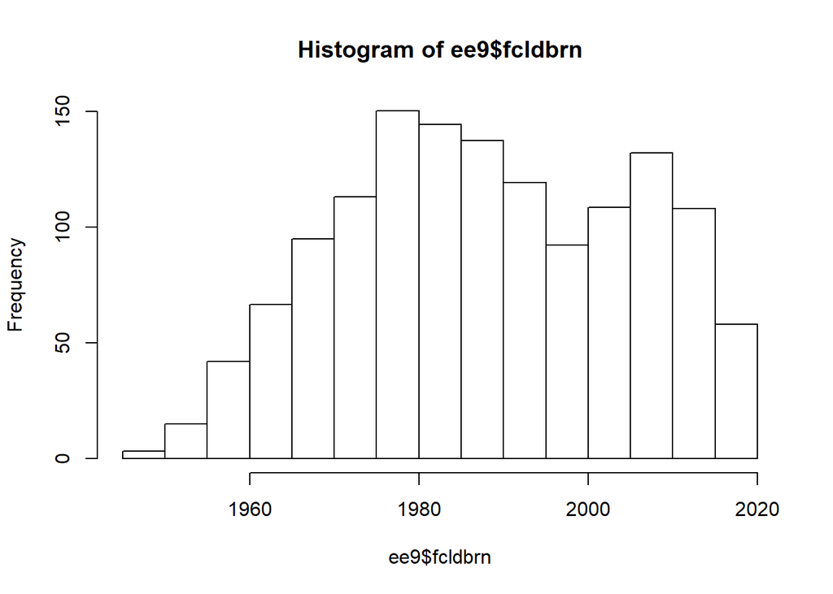

```r
library(weights)
wtd.hist(ee9$fcldbrn, weight = ee9$pspwght)
```

Arvutame tunnusesse `fcldbthage` respondendi vanuse esimese lapse sünni ajal ja vaatame tunnuse jaotust.

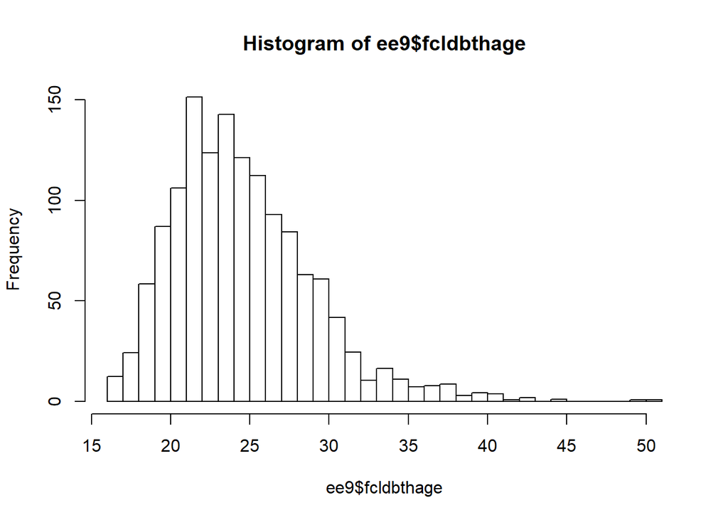

```r
library(dplyr)
ee9 <- ee9 %>%
  mutate(fcldbthage = fcldbrn - ee9$yrbrn)

wtd.hist(ee9$fcldbthage, weight = ee9$pspwght, breaks = 25, freq = T)
```

Sama tulemuse (tehniliselt tulpdiagrammina) koos sagedustabeliga saaksime funktsiooniga `freq` paketist `descr`.

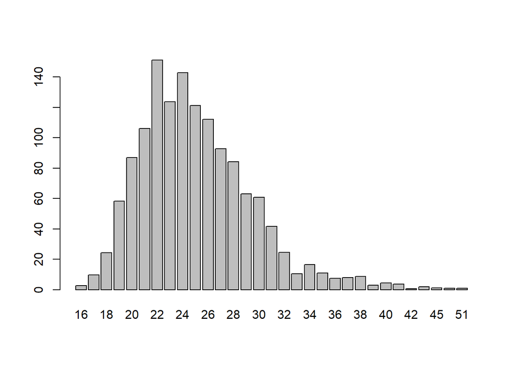

```
## ee9$fcldbthage
##       Frequency   Percent Valid Percent
## 16       2.7851   0.14627       0.20112
## 17       9.6056   0.50449       0.69364
## 18      24.2241   1.27227       1.74929
## 19      58.4004   3.06725       4.21725
## 20      86.9470   4.56654       6.27868
## 21     106.0809   5.57148       7.66039
## 22     151.1602   7.93909      10.91569
## 23     123.6218   6.49274       8.92707
## 24     142.7247   7.49605      10.30654
## 25     121.1144   6.36105       8.74600
## 26     112.1397   5.88969       8.09792
## 27      92.8008   4.87399       6.70140
## 28      84.3175   4.42844       6.08880
```

[output cut: 20 more lines]

```r
descr::freq(ee9$fcldbthage, w = ee9$pspwght)
```

Meil on olemas nüüd tunnus selle kohta, mis vanuses kellelgi sündmus (esimese lapse sünd) toimus, aga meil peaks olema ka tunnus selle kohta, kellel sündmus (lapse sünd) üldse toimus. ESS-i andmestikus juba on suunav tunnus, mis seda näitab, `bthcld`. Vaatame, mis on selle tunnuse täpsem nimetus ja kategooriad. Mingi ülevaate, millest mõnel juhul piisab, saab funktsiooniga `str` ehk *structure*.

```r
str(ee9$bthcld)
```

```
##  dbl+lbl [1:1904] 1, 1, 1, 1, 1, 1, 1, 1, 1, 1, 1, 2, 1, 1, 1, 1, 1, 1, 1, ...
##  @ label       : chr "Ever given birth to/ fathered a child"
##  @ format.stata: chr "%12.0g"
##  @ labels      : Named num [1:5] 1 2 NA NA NA
##   ..- attr(*, "names")= chr [1:5] "Yes" "No" "Refusal" "Don't know" ...
```

Täpsema ülevaate saab funktsiooniga `attributes`.

```r
attributes(ee9$bthcld)
```

```
## $label
## [1] "Ever given birth to/ fathered a child"
##
## $format.stata
## [1] "%12.0g"
##
## $class
## [1] "haven_labelled" "vctrs_vctr"     "double"
##
## $labels
##        Yes         No    Refusal Don't know  No answer
##          1          2         NA         NA         NA
```

Näeme, et tunnuses on valiidseteks väärtusteks kaks kategooriat nagu peakski olema, aga elukestuskõverate arvutamiseks peaks sündmuse mittetoimumine (väärtus 2 ehk ‘No’) olema väärtusega 0.

```r
ee9 <- ee9 %>%
  mutate(bthcld01 = ifelse(bthcld == 2, 0, 1))

descr::freq(ee9$bthcld, w = ee9$pspwght, plot = FALSE)
```

```
## Ever given birth to/ fathered a child
##       Frequency Percent
## 1          1388    72.9
## 2           516    27.1
## Total      1904   100.0
```

```r
descr::freq(ee9$bthcld01, w = ee9$pspwght, plot = FALSE)
```

```
## ee9$bthcld01
##       Frequency Percent
## 0           516    27.1
## 1          1388    72.9
## Total      1904   100.0
```

Teeme elukestuskõvera.

```r
fit2 <- survfit(Surv(fcldbthage, bthcld01) ~ 1, data = ee9, weights = pspwght)
summary(fit2)
```

```
## Call: survfit(formula = Surv(fcldbthage, bthcld01) ~ 1, data = ee9,
##     weights = pspwght)
##
## 461 observations deleted due to missingness
##  time   n.risk n.event survival  std.err lower 95% CI upper 95% CI
##    16 1384.797   2.785  0.99799 0.001176     9.96e-01      1.00000
##    17 1382.012   9.606  0.99105 0.002422     9.86e-01      0.99581
##    18 1372.406  24.224  0.97356 0.004148     9.65e-01      0.98172
##    19 1348.182  58.400  0.93139 0.006783     9.18e-01      0.94478
##    20 1289.782  86.947  0.86860 0.008861     8.51e-01      0.88614
##    21 1202.835 106.081  0.79200 0.010795     7.71e-01      0.81344
##    22 1096.754 151.160  0.68284 0.012492     6.59e-01      0.70777
##    23  945.594 123.622  0.59357 0.013251     5.68e-01      0.62012
##    24  821.972 142.725  0.49050 0.013557     4.65e-01      0.51781
##    25  679.247 121.114  0.40304 0.013354     3.78e-01      0.43008
```

[output cut: 21 more lines]

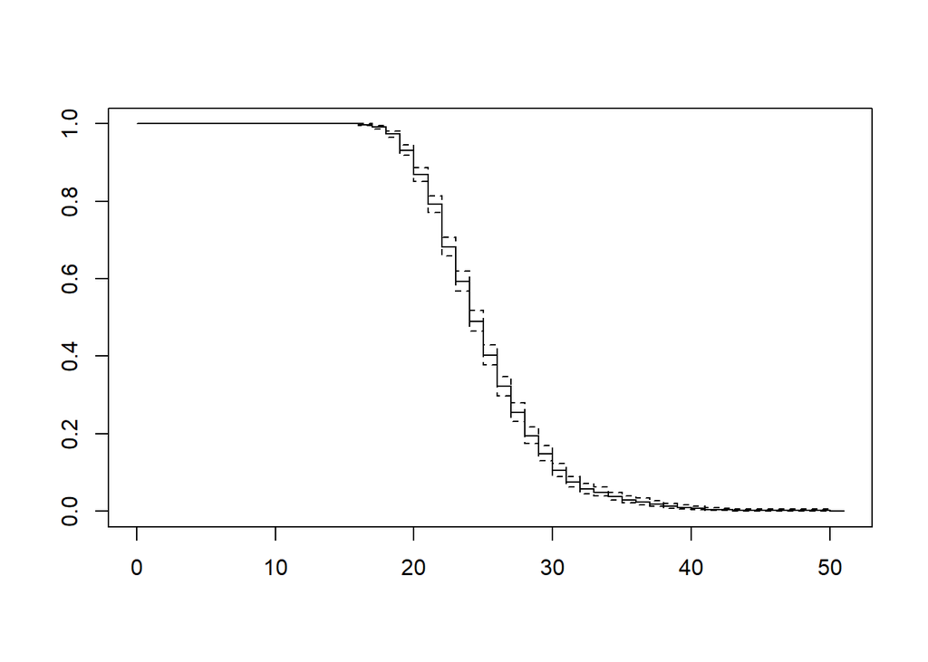

```r
plot(fit2, conf.int = T, mark.time = T)
```

Saime elukestuskõvera, aga see võtab arvesse ainult neid indiviide, kellel sündmus toimus, sest ülejäänutel ei ole tunnuses, mis näitab indiviidi vanust esimese lapse sünnil, mingit väärtust. Neil eii saagi seal mingit väärtust olla, sest neil pole lapsi sündinud, samas ei tea me (vähemalt nooremate vastajate puhul) kindlalt, et neil lapsi ka tulevikus ei sünni. Seega on tegu tsenseeritud indiviididega, kelle puhul peaks tunnuse `fcldbthage` väärtuseks olema vanus küsitluse hetkel.

Lisame tunnusesse `fcldbthage` tsenseeritud indiviidide andmed.

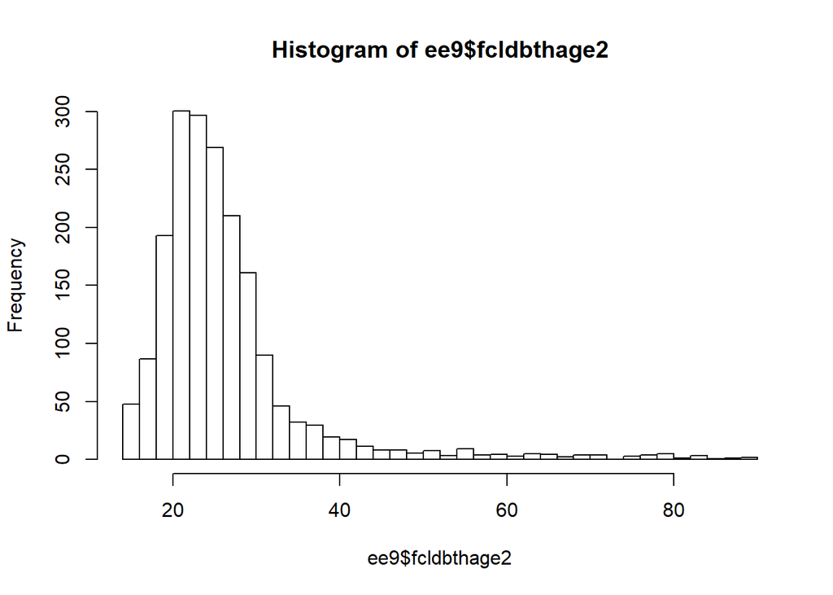

```r
ee9 <- ee9 %>%
  mutate(fcldbthage2 = ifelse(bthcld01 == 1, fcldbthage, agea))

wtd.hist(ee9$fcldbthage2, weight = ee9$pspwght, breaks = 30)
```

Teeme elukestuskõvera, võttes arvesse ka tsenseeritud indiviidide andmed. Vaatame, kuidas elukestuskõvera kuju muutus.

```r
fit3 <- survfit(Surv(fcldbthage2, bthcld01) ~ 1, data = ee9, weights = pspwght)
summary(fit3)
```

```
## Call: survfit(formula = Surv(fcldbthage2, bthcld01) ~ 1, data = ee9,
##     weights = pspwght)
##
## 3 observations deleted due to missingness
##  time n.risk n.event survival  std.err lower 95% CI upper 95% CI
##    16 1880.7   2.785    0.999 0.000866        0.997        1.000
##    17 1853.0   9.606    0.993 0.001804        0.990        0.997
##    18 1817.2  24.224    0.980 0.003132        0.974        0.986
##    19 1766.2  58.400    0.948 0.005223        0.938        0.958
##    20 1682.8  86.947    0.899 0.006947        0.885        0.912
##    21 1573.3 106.081    0.838 0.008655        0.821        0.855
##    22 1443.0 151.160    0.750 0.010340        0.730        0.771
##    23 1273.2 123.622    0.677 0.011284        0.656        0.700
##    24 1138.1 142.725    0.593 0.011997        0.569        0.617
##    25  976.7 121.114    0.519 0.012318        0.495        0.544
```

[output cut: 21 more lines]

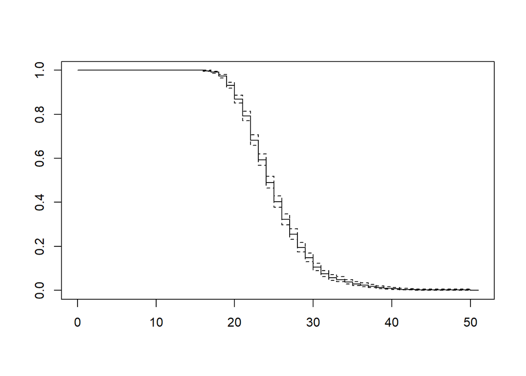

```r
plot(fit2, conf.int = T, mark.time = F, xlim = c(0,51))
```

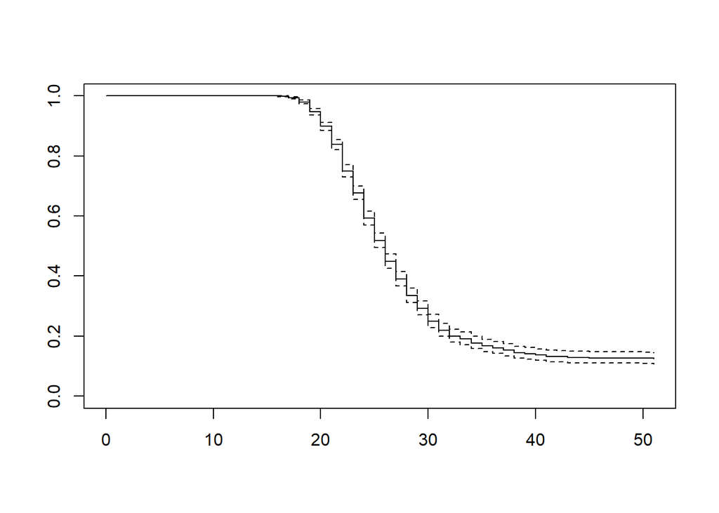

```r
plot(fit3, conf.int = T, mark.time = F, xlim = c(0,51))
```

Elukestuskõvera kuju põhimõtteliselt jäi samaks, välja arvatud tõik, et kõver ei jõudnud y-teljel nulli, vaid jäi 0,124 peale pidama (täpset väärtust vt `summary(fit3)` tabeli veerust `survival`). See on seetõttu, et lapsi mitte saanute seas on vanemaid inimesi. Sisuliselt tähendab see seda, et 51. eluaastaks on sündmuse mittetoimumise tõenäosus ehk tõenäosus, et lapsi pole saadud 0,124. Jaotusfunktsiooni väärtus on samas vanuses 1 - 0,124 = 0,876 ehk tõenäosus, et 51. eluaastaks on lapsi saadud, on 0,876.

## Kaplan-Meier rühmiti

Eelnev näide püüdis ära kasutada mingeid ajasõltuvaid andmeid, mida üks tavaline küsitlusuuring võib sisaldada. Sisulisel tasandil ei olnud see kõige õnnestunum, sest saadud sündmuse toimumise tõenäosusi on keeruline kuidagi üldistada - olid ju sündmused (laste sünnid) toimunud intevjueeritute eludes väga erinevatel aegadel (alates umbes eelmise sajandi keskpaigast praeguse ajani), mil nii esmasünnitamise vanus kui elu jooksul saadavate laste arv on olnud väga erinevad. Seetõttu ei ütle saadud sündmuse mittetoimumise tõenäosused konkreetses vanuses meile kuigi palju esimese lapse sünni mittetoimumise tõenäosuse (sisuliselt lastetu olemise tõenäosuse) kohta mingis vanuses aastal 2022.

Teeme analüüsi sisulises plaanis natuke mõistlikumaks. Uurime elukestuskõveraid erinevates kohortides. Jagame valimi kolmeks enam-vähem võrdse suurusega sünnikohordiks.

```r
ee9$yrbrncat <- cut(ee9$yrbrn, c(1927, 1960, 1980, 2003))

fit_yrbrn <- survfit(Surv(fcldbthage2, bthcld01) ~ yrbrncat, data = ee9, weights = pspwght)

summary(fit_yrbrn)
```

```
## Call: survfit(formula = Surv(fcldbthage2, bthcld01) ~ yrbrncat, data = ee9,
##     weights = pspwght)
##
## 3 observations deleted due to missingness
##                 yrbrncat=(1.93e+03,1.96e+03]
##  time n.risk n.event survival std.err lower 95% CI upper 95% CI
##    16  656.9   0.746   0.9989 0.00114       0.9966       1.0000
##    17  656.1   3.075   0.9942 0.00245       0.9894       0.9990
##    18  653.1   7.558   0.9827 0.00427       0.9743       0.9911
##    19  645.5   9.998   0.9675 0.00596       0.9558       0.9792
##    20  635.5  38.009   0.9096 0.00991       0.8904       0.9292
##    21  597.5  39.324   0.8497 0.01272       0.8252       0.8750
##    22  558.2  69.206   0.7444 0.01603       0.7136       0.7765
##    23  489.0  61.323   0.6510 0.01776       0.6171       0.6868
##    24  427.7  73.459   0.5392 0.01880       0.5036       0.5773
```

[output cut: 75 more lines]

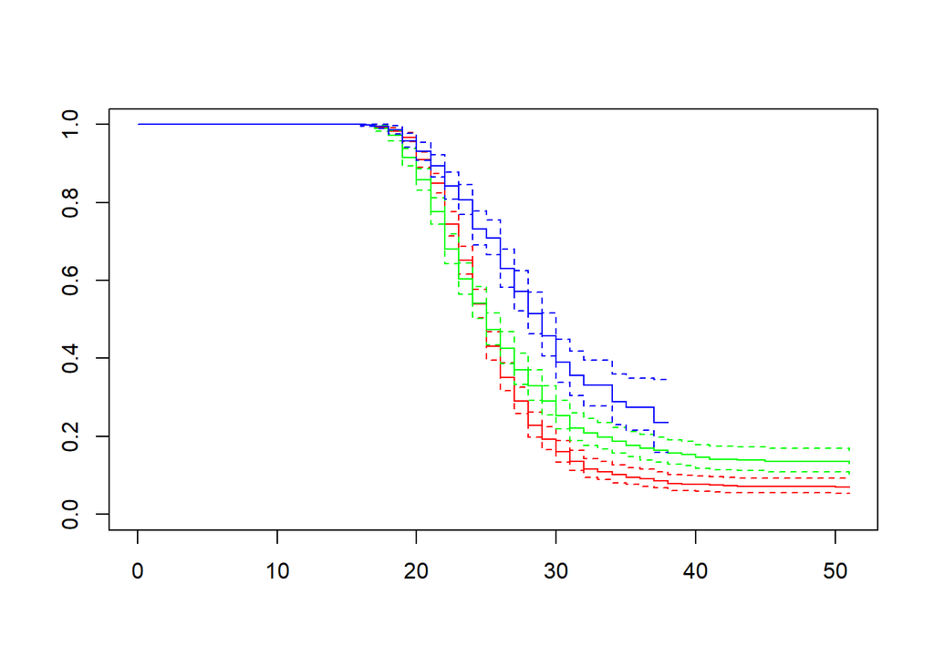

```r
plot(fit_yrbrn, col = c("red", "green", "blue"), conf.int = T, mark.time = F, xlim = c(0,51))
```

Seni oleme elukestuskõverate visuaalseks kujutamiseks kasutanud funktsiooni `plot`, mis on lihtsam ja sobib kiireks andmete (avastuslikuks) visualiseerimiseks, samas on see ka primitiivsem - mitme kõvera puhul muutub nende usaldusvahemike eristamine keeruliseks. Nagu ikka, tuleb appi `ggplot2` ja selle põhjal koostatud pakett `survminer`.

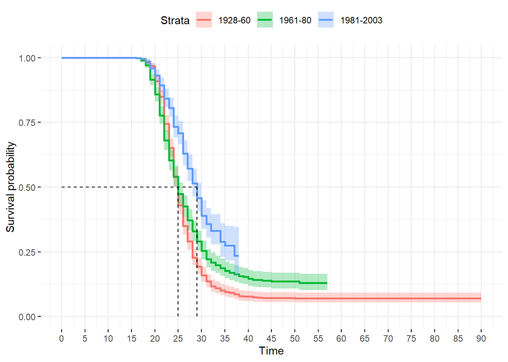

```r
library(survminer)
ggsurvplot(fit_yrbrn, data = ee9, conf.int = TRUE,
           censor = FALSE, # ei too kõveratel välja vanuseid, mil esines tsenseeritud indiviide
           legend.labs = c("1928-60", "1961-80", "1981-2003"),
           surv.median.line = "hv", # toome välja elukestuse mediaanväärtused
           break.time.by = 5,
           ggtheme = theme_minimal())
```

Kuna kõrgeim vanus, mil meie andmetes lapsi saadi, oli 51, siis võiks x-teljel kuvada ainult väärtused vahemikus 0-51 (või isegi 16-51). Kahjuks on ggploti uuendustega tekkinud häda, et siis lähevad osad usaldusvahemikud kaotsi. Kaotsi ei lähe nad juhul, kui märkida joonisel ainult usaldspiirid, aga see vähendab joonise loetavust:

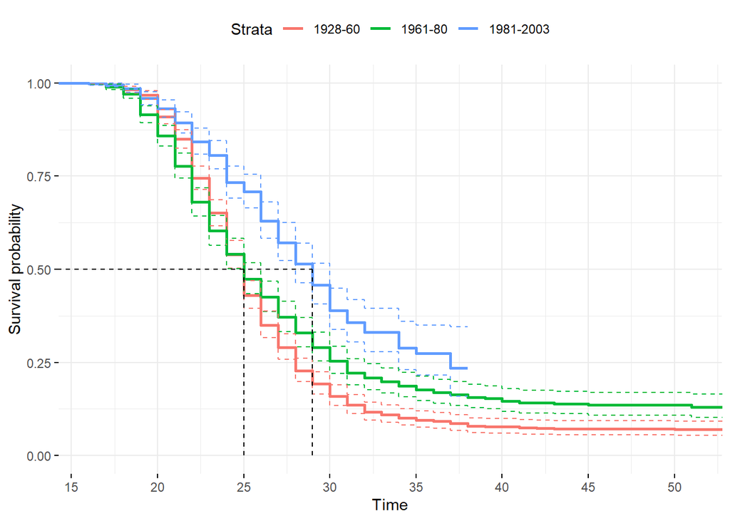

```r
ggsurvplot(fit_yrbrn, data = ee9, conf.int = TRUE,
           censor = FALSE,
           legend.labs = c("1928-60", "1961-80", "1981-2003"),
           surv.median.line = "hv",
           break.time.by = 5,
           ggtheme = theme_minimal(),
           xlim = c(16, 51),
           conf.int.style = "step")
```

Loetavama joonise saame, kui piirame tunnuse `fcldbthage2` väärtused 52-ga. Saame seda teha, sest kõrgeim esimeses lapse saamise vanus andmestikus on 51, sellest kõrgemates vanustes esinevad ainult tsenseeritud episoodid - nende puhul pole elukestusfunktsiooni arvutamisel vahet, mis vanuses tsenseerimine toimub.

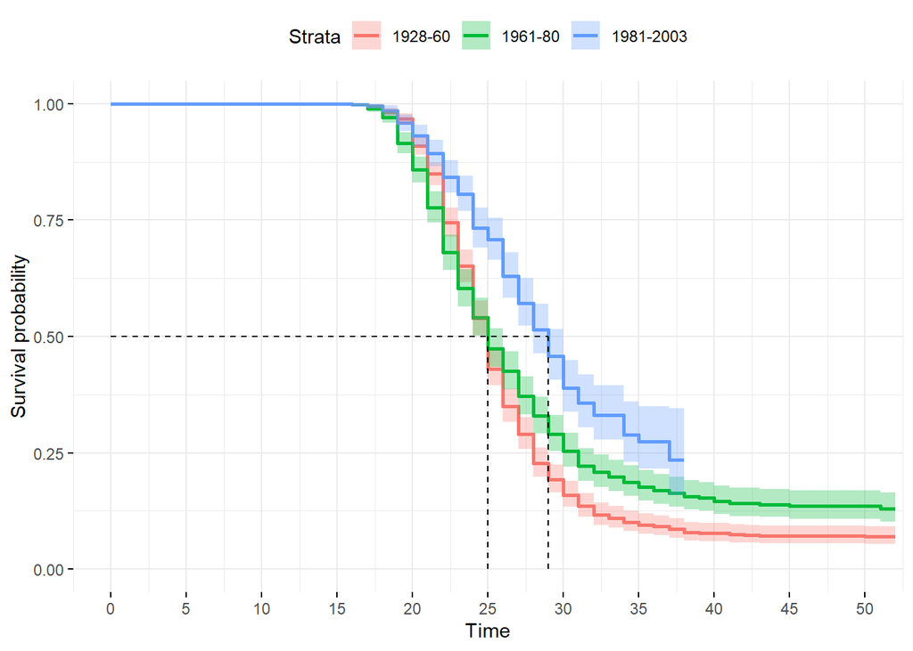

```r
ee9 <- ee9 %>%
  mutate(fcldbthage3 = ifelse(fcldbthage2 < 52, fcldbthage2, 52))

fit_yrbrn2 <- survfit(Surv(fcldbthage3, bthcld01) ~ yrbrncat, data = ee9, weights = pspwght)

ggsurvplot(fit_yrbrn2, data = ee9, conf.int = TRUE,
           censor = FALSE,
           legend.labs = c("1928-60", "1961-80", "1981-2003"),
           surv.median.line = "hv",
           break.time.by = 5,
           ggtheme = theme_minimal())
```

Mida saame jooniselt järeldada esimese lapse sünni mittetoimumise tõenäosuse kohta vanuse lõikes eri sünnikohortides? Eri kohortide võrdluses? Mida näitavad siin usaldusvahemikud?

Antud tõenäosust on sisuliselt mõnevõrra keeruline tõlgendada (vähemalt sõnadesse panna). Siin võib abiks olla kumulatiivne jaotusfunktsioon, mille saame, kui lisame funktsiooni `ggsurvplot` argumendiks `fun = "event"`.

**Harjutus.** Arvutage esimese lapse sünni mittetoimumise tõenäosused vanuse lõikes eri haridustee pikkuse korral. Haridustee pikkuse tunnus tehke kategoriaalseks, võtke kategooriateks 3-9, 10-12, 13-15 ja 16+ aastat. Koostage vastavad elukestuskõverad joonisel.

Püüdke joonise alusel vastata järgmistele küsimustele.

- Kas esimese lapse saamise vanus on seotud haridustee pikkusega?
- Milline see seos on, st millised on erinevused esimese lapse saamise vanuses haridustee pikkuse lõikes?

```r
ee9$eduyrscat4 <- cut(ee9$_______, c(___________))

fit_eduyrs <- survfit(Surv(____________, __________) ~ __________, data = ________, weights = pspwght)

plot(_____________, col = c("black", "red", "blue", "green"))

ggsurvplot(___________, data = ________, conf.int = TRUE,
           censor = F,
           legend.labs = ___________________________,
           surv.median.line = "hv",
           ggtheme = theme_minimal())
```

## Logaritmiline astaktest *(log-rank test)*

Eelnevast juba enam-vähem nägime, kas eri sünnikohortide ja haridustee pikkuse gruppide elukestuskõverad erinevad, teeme kindluse mõttes ka logaritmilised astakmärgitestid.

```r
survdiff(Surv(fcldbthage3, bthcld01) ~ yrbrncat, data = ee9)
```

```
## Call:
## survdiff(formula = Surv(fcldbthage3, bthcld01) ~ yrbrncat, data = ee9)
##
## n=1901, 3 observations deleted due to missingness.
##
##                                N Observed Expected (O-E)^2/E (O-E)^2/V
## yrbrncat=(1.93e+03,1.96e+03] 747      693      572     25.40     47.18
## yrbrncat=(1.96e+03,1.98e+03] 597      521      496      1.25      2.16
## yrbrncat=(1.98e+03,2e+03]    557      229      375     56.53     86.57
##
##  Chisq= 94  on 2 degrees of freedom, p= <2e-16
```

```r
ee9$eduyrscat4 <- cut(ee9$eduyrs, c(3, 9, 12, 15, 30))
survdiff(Surv(fcldbthage3, bthcld01) ~ eduyrscat4, data = ee9)
```

```
## Call:
## survdiff(formula = Surv(fcldbthage3, bthcld01) ~ eduyrscat4,
##     data = ee9)
##
## n=1901, 3 observations deleted due to missingness.
##
##                      N Observed Expected (O-E)^2/E (O-E)^2/V
## eduyrscat4=(3,9]   205      144      130     1.551     1.902
## eduyrscat4=(9,12]  689      532      432    23.188    37.002
## eduyrscat4=(12,15] 451      342      335     0.156     0.227
## eduyrscat4=(15,30] 556      425      546    27.007    48.894
##
##  Chisq= 58.3  on 3 degrees of freedom, p= 1e-12
```

Hii-ruut-statistiku olulisuse tõenäosused on mõlemal juhul väga väikesed, seega saame kinnitada (vähemalt osade) elukestuskõverate erinevust. Millised elukestuskõverad täpselt üksteisest erinevad, seda antud test meile ei ütle, selleks tuleb ikkagi uurida elukestuskõverate diagramme või teha teste gruppide võrdluses.

Haridusgruppide puhul kattusid elukestuskõverad kõige enam lühema haridusteega indiviidide gruppides, uurime nende erinevust logaritmilise astaktesti abil.

```r
survdiff(Surv(fcldbthage3, bthcld01) ~ eduyrscat4, data = subset(ee9, eduyrs <= 12))
```

```
## Call:
## survdiff(formula = Surv(fcldbthage3, bthcld01) ~ eduyrscat4,
##     data = subset(ee9, eduyrs <= 12))
##
## n=894, 1 observation deleted due to missingness.
##
##                     N Observed Expected (O-E)^2/E (O-E)^2/V
## eduyrscat4=(3,9]  205      144      153     0.529     0.775
## eduyrscat4=(9,12] 689      532      523     0.155     0.775
##
##  Chisq= 0.8  on 1 degrees of freedom, p= 0.4
```

Teststatistiku olulisuse tõenäosus on kõrge, ühelgi olulisuse nivool elukestuskõverate erinevust kinnitada ei saa. Kui vaadata vastavat diagrammi, siis tegelikult on ka näha, et need kõverad lõikuvad kaks korda, nii et logaritmilise astaktesti eeldused ei ole siin täidetud, samas kõverate lõikumine ja küllaltki sarnane kuju näitavad ka ise ära, et mingit põhimõttelist erinevust on nende kahe kõvera erinevuse puhul raske väita.

Kontrollime ka kahe ülejäänud grupi elukestuskõverate erinevust.

```r
survdiff(Surv(fcldbthage3, bthcld01) ~ eduyrscat4, data = subset(ee9, eduyrs > 12))
```

```
## Call:
## survdiff(formula = Surv(fcldbthage3, bthcld01) ~ eduyrscat4,
##     data = subset(ee9, eduyrs > 12))
##
## n=1007, 2 observations deleted due to missingness.
##
##                      N Observed Expected (O-E)^2/E (O-E)^2/V
## eduyrscat4=(12,15] 451      342      286     10.77      19.2
## eduyrscat4=(15,30] 556      425      481      6.42      19.2
##
##  Chisq= 19.2  on 1 degrees of freedom, p= 1e-05
```

Teststatistiku olulisuse tõenäosus on siin väga väike, nii et saame kinnitada esimese lapse saamise kumulatiivsete tõenäosuste erinevust nendes kahes grupis. Sisuliselt tähendab see ikka seda, et lapsevanema vanus esimese lapse sünnil on olenevalt haridustee pikkusest nendes kahes grupis erinev.